# Useful R Stuff

# Working with dataframes

## thinkr::peep() - see intermediate stages of piped dfs

```r
iris %>%
  thinkr::peep(head) %>%
  rename(species = Species)
```

```
##   Sepal.Length Sepal.Width Petal.Length Petal.Width Species
## 1          5.1         3.5          1.4         0.2  setosa
## 2          4.9         3.0          1.4         0.2  setosa
## 3          4.7         3.2          1.3         0.2  setosa
## 4          4.6         3.1          1.5         0.2  setosa
## 5          5.0         3.6          1.4         0.2  setosa
## 6          5.4         3.9          1.7         0.4  setosa
```

```
##     Sepal.Length Sepal.Width Petal.Length Petal.Width    species
## 1            5.1         3.5          1.4         0.2     setosa
## 2            4.9         3.0          1.4         0.2     setosa
## 3            4.7         3.2          1.3         0.2     setosa
## 4            4.6         3.1          1.5         0.2     setosa
## 5            5.0         3.6          1.4         0.2     setosa
## 6            5.4         3.9          1.7         0.4     setosa
## 7            4.6         3.4          1.4         0.3     setosa
## 8            5.0         3.4          1.5         0.2     setosa
## 9            4.4         2.9          1.4         0.2     setosa
## 10           4.9         3.1          1.5         0.1     setosa
## 11           5.4         3.7          1.5         0.2     setosa
## 12           4.8         3.4          1.6         0.2     setosa
## 13           4.8         3.0          1.4         0.1     setosa
## 14           4.3         3.0          1.1         0.1     setosa
```

[output cut: 136 more lines]

```r
iris %>%
  thinkr::peep(head(., n = 7)) %>%
  rename(species = Species)
```

```
##   Sepal.Length Sepal.Width Petal.Length Petal.Width Species
## 1          5.1         3.5          1.4         0.2  setosa
## 2          4.9         3.0          1.4         0.2  setosa
## 3          4.7         3.2          1.3         0.2  setosa
## 4          4.6         3.1          1.5         0.2  setosa
## 5          5.0         3.6          1.4         0.2  setosa
## 6          5.4         3.9          1.7         0.4  setosa
## 7          4.6         3.4          1.4         0.3  setosa
```

```
##     Sepal.Length Sepal.Width Petal.Length Petal.Width    species
## 1            5.1         3.5          1.4         0.2     setosa
## 2            4.9         3.0          1.4         0.2     setosa
## 3            4.7         3.2          1.3         0.2     setosa
## 4            4.6         3.1          1.5         0.2     setosa
## 5            5.0         3.6          1.4         0.2     setosa
## 6            5.4         3.9          1.7         0.4     setosa
## 7            4.6         3.4          1.4         0.3     setosa
## 8            5.0         3.4          1.5         0.2     setosa
## 9            4.4         2.9          1.4         0.2     setosa
## 10           4.9         3.1          1.5         0.1     setosa
## 11           5.4         3.7          1.5         0.2     setosa
## 12           4.8         3.4          1.6         0.2     setosa
## 13           4.8         3.0          1.4         0.1     setosa
## 14           4.3         3.0          1.1         0.1     setosa
```

[output cut: 136 more lines]

## janitor - clean dirty data, tabulating tools, adornments

Clean up column names

```r
library(janitor)
```

```r
# Create a data.frame with dirty names
test_df <- as.data.frame(matrix(ncol = 6))
names(test_df) <- c("firstName", "ábc@!*", "% successful (2009)",
                    "REPEAT VALUE", "REPEAT VALUE", "")

test_df %>%
  clean_names()
```

```
##   first_name abc percent_successful_2009 repeat_value repeat_value_2  x
## 1         NA  NA                      NA           NA             NA NA
```

```r
test_df %>%
  clean_names(case = "small_camel")
```

```
##   firstName abc percentSuccessful2009 repeatValue repeatValue_2  x
## 1        NA  NA                    NA          NA            NA NA
```

Compare two or more DFs to see if they have the same types of columns and can be rbound

```r
df1 <- data.frame(a = 1:2, b = c("big", "small"))
df2 <- data.frame(a = 10:12, b = c("medium", "small", "big"), c = 0, stringsAsFactors = TRUE) # here, column b is a factor
df3 <- df1 %>%
  dplyr::mutate(b = as.character(b))

compare_df_cols(df1, df2, df3)
```

```
##   column_name       df1     df2       df3
## 1           a   integer integer   integer
## 2           b character  factor character
## 3           c      <NA> numeric      <NA>
```

## janitor::tabyl - compare combinations of varibales like xtab

```r
mtcars %>%
  tabyl(gear, cyl)
```

```
##  gear 4 6  8
##     3 1 2 12
##     4 8 4  0
##     5 2 1  2
```

You can “adorn” tabuls with totals, percentages, and more

```r
mtcars %>%
  tabyl(gear, cyl) %>%
  adorn_totals("col") %>%
  adorn_percentages("row") %>%
  adorn_pct_formatting(digits = 2) %>%
  adorn_ns() %>%
  adorn_title()
```

```
##              cyl
##  gear          4          6           8        Total
##     3  6.67% (1) 13.33% (2) 80.00% (12) 100.00% (15)
##     4 66.67% (8) 33.33% (4)  0.00%  (0) 100.00% (12)
##     5 40.00% (2) 20.00% (1) 40.00%  (2) 100.00%  (5)
```

[More on tabyls](http://sfirke.github.io/janitor/articles/tabyls.html)

## diffobj - compare two dfs (or other objects) to see what’s changed between them

NB: in RStudio this will open a colorful thing in the Viewer that’s easy to read

```r
library(diffobj)
a <- b <- matrix(1:100, ncol=2)
a <- a[-20,]
b <- b[-45,]
b[c(18, 44)] <- 999
diffPrint(target=a, current=b)
```

```
## < a                > b
## @@ 17,6 @@         @@ 17,7 @@
## ~       [,1] [,2]  ~       [,1] [,2]
##   [16,]   16   66    [16,]   16   66
##   [17,]   17   67    [17,]   17   67
## < [18,]   18   68  > [18,]  999   68
##   [19,]   19   69    [19,]   19   69
## ~                  > [20,]   20   70
##   [20,]   21   71    [21,]   21   71
##   [21,]   22   72    [22,]   22   72
## @@ 42,6 @@         @@ 43,5 @@
##   [41,]   42   92    [42,]   42   92
##   [42,]   43   93    [43,]   43   93
## < [43,]   44   94  > [44,]  999   94
## < [44,]   45   95  ~
##   [45,]   46   96    [45,]   46   96
##   [46,]   47   97    [46,]   47   97
```

```r
diffChr(letters[1:3], c("a", "B", "c"))
```

```
## < letters..  > c("a", ..
## @@ 1,3 @@    @@ 1,3 @@
##   a            a
## < b          > B
##   c            c
```

## fuzzyjoin: Join dfs on inexact matching

Among other options:

- Numeric values that are within some tolerance (difference_inner_join)
- Strings that are similar in Levenshtein/cosine/Jaccard distance, or other metrics from the stringdist package (stringdist_inner_join)
- A regular expression in one column matching to another (regex_inner_join)

# Summarizing

## skimr::skim() - nice summary statistics for dfs and the like

```r
library(skimr)
iris %>%
  group_by(Species) %>%
  skim() %>%
  print() # print() only necessary so we don't get a kable table in this document
```

```
## ── Data Summary ────────────────────────
##                            Values
## Name                       Piped data
## Number of rows             150
## Number of columns          5
## _______________________
## Column type frequency:
##   numeric                  4
## ________________________
## Group variables            Species
##
## ── Variable type: numeric ──────────────────────────────────────────────────────
##    skim_variable Species    n_missing complete_rate  mean    sd  p0  p25  p50
##  1 Sepal.Length  setosa             0             1 5.01  0.352 4.3 4.8  5
##  2 Sepal.Length  versicolor         0             1 5.94  0.516 4.9 5.6  5.9
##  3 Sepal.Length  virginica          0             1 6.59  0.636 4.9 6.22 6.5
##  4 Sepal.Width   setosa             0             1 3.43  0.379 2.3 3.2  3.4
##  5 Sepal.Width   versicolor         0             1 2.77  0.314 2   2.52 2.8
##  6 Sepal.Width   virginica          0             1 2.97  0.322 2.2 2.8  3
##  7 Petal.Length  setosa             0             1 1.46  0.174 1   1.4  1.5
##  8 Petal.Length  versicolor         0             1 4.26  0.470 3   4    4.35
##  9 Petal.Length  virginica          0             1 5.55  0.552 4.5 5.1  5.55
## 10 Petal.Width   setosa             0             1 0.246 0.105 0.1 0.2  0.2
## 11 Petal.Width   versicolor         0             1 1.33  0.198 1   1.2  1.3
## 12 Petal.Width   virginica          0             1 2.03  0.275 1.4 1.8  2
##     p75 p100 hist
##  1 5.2   5.8 ▃▃▇▅▁
##  2 6.3   7   ▂▇▆▃▃
##  3 6.9   7.9 ▁▃▇▃▂
##  4 3.68  4.4 ▁▃▇▅▂
##  5 3     3.4 ▁▅▆▇▂
##  6 3.18  3.8 ▂▆▇▅▁
##  7 1.58  1.9 ▁▃▇▃▁
##  8 4.6   5.1 ▂▂▇▇▆
##  9 5.88  6.9 ▃▇▇▃▂
## 10 0.3   0.6 ▇▂▂▁▁
## 11 1.5   1.8 ▅▇▃▆▁
## 12 2.3   2.5 ▂▇▆▅▇
```

```
## $numeric
##
## ── Variable type: numeric ──────────────────────────────────────────────────────
##    skim_variable Species  n_missing complete_rate  mean    sd  p0  p25  p50  p75
##  1 Sepal.Length  setosa           0             1 5.01  0.352 4.3 4.8  5    5.2
##  2 Sepal.Length  versico…         0             1 5.94  0.516 4.9 5.6  5.9  6.3
##  3 Sepal.Length  virgini…         0             1 6.59  0.636 4.9 6.22 6.5  6.9
##  4 Sepal.Width   setosa           0             1 3.43  0.379 2.3 3.2  3.4  3.68
##  5 Sepal.Width   versico…         0             1 2.77  0.314 2   2.52 2.8  3
##  6 Sepal.Width   virgini…         0             1 2.97  0.322 2.2 2.8  3    3.18
##  7 Petal.Length  setosa           0             1 1.46  0.174 1   1.4  1.5  1.58
##  8 Petal.Length  versico…         0             1 4.26  0.470 3   4    4.35 4.6
##  9 Petal.Length  virgini…         0             1 5.55  0.552 4.5 5.1  5.55 5.88
## 10 Petal.Width   setosa           0             1 0.246 0.105 0.1 0.2  0.2  0.3
## 11 Petal.Width   versico…         0             1 1.33  0.198 1   1.2  1.3  1.5
## 12 Petal.Width   virgini…         0             1 2.03  0.275 1.4 1.8  2    2.3
## # … with 2 more variables: p100 <dbl>, hist <chr>
```

```r
iris %>%
  skim() %>%
  summary() %>%
  print() # print() only necessary so we don't get a kable table in this document
```

```
## ── Data Summary ────────────────────────
##                            Values
## Name                       Piped data
## Number of rows             150
## Number of columns          5
## _______________________
## Column type frequency:
##   factor                   1
##   numeric                  4
## ________________________
## Group variables            None
```

```r
iris %>%
  skim(Sepal.Length, Petal.Length) %>%  # tidyselect columns to summarize
  print() # print() only necessary so we don't get a kable table in this document
```

```
## ── Data Summary ────────────────────────
##                            Values
## Name                       Piped data
## Number of rows             150
## Number of columns          5
## _______________________
## Column type frequency:
##   numeric                  2
## ________________________
## Group variables            None
##
## ── Variable type: numeric ──────────────────────────────────────────────────────
##   skim_variable n_missing complete_rate mean    sd  p0 p25  p50 p75 p100 hist
## 1 Sepal.Length          0             1 5.84 0.828 4.3 5.1 5.8  6.4  7.9 ▆▇▇▅▂
## 2 Petal.Length          0             1 3.76 1.77  1   1.6 4.35 5.1  6.9 ▇▁▆▇▂
```

```
## $numeric
##
## ── Variable type: numeric ──────────────────────────────────────────────────────
##   skim_variable n_missing complete_rate mean    sd  p0 p25  p50 p75 p100 hist
## 1 Sepal.Length          0             1 5.84 0.828 4.3 5.1 5.8  6.4  7.9 ▆▇▇▅▂
## 2 Petal.Length          0             1 3.76 1.77  1   1.6 4.35 5.1  6.9 ▇▁▆▇▂
```

You can do cool stuff in the pipeline with it

```r
iris %>%
  skim() %>%
  dplyr::filter(numeric.sd > 1) %>% # "numeric" is the variable type that we're targeting
  print()
```

```
## ── Data Summary ────────────────────────
##                            Values
## Name                       Piped data
## Number of rows             150
## Number of columns          5
## _______________________
## Column type frequency:
##   numeric                  1
## ________________________
## Group variables            None
##
## ── Variable type: numeric ──────────────────────────────────────────────────────
##   skim_variable n_missing complete_rate mean   sd p0 p25  p50 p75 p100 hist
## 1 Petal.Length          0             1 3.76 1.77  1 1.6 4.35 5.1  6.9 ▇▁▆▇▂
```

```
## $numeric
##
## ── Variable type: numeric ──────────────────────────────────────────────────────
##   skim_variable n_missing complete_rate mean   sd p0 p25  p50 p75 p100 hist
## 1 Petal.Length          0             1 3.76 1.77  1 1.6 4.35 5.1  6.9 ▇▁▆▇▂
```

# Plotting

## Khroma - color scales that are nice and colorblind friendly

https://packages.tesselle.org/khroma/

```r
library(khroma)
bright <- colour("bright")
bright(7)
```

```
##      blue       red     green    yellow      cyan    purple      grey
## "#4477AA" "#EE6677" "#228833" "#CCBB44" "#66CCEE" "#AA3377" "#BBBBBB"
## attr(,"missing")
## [1] NA
```

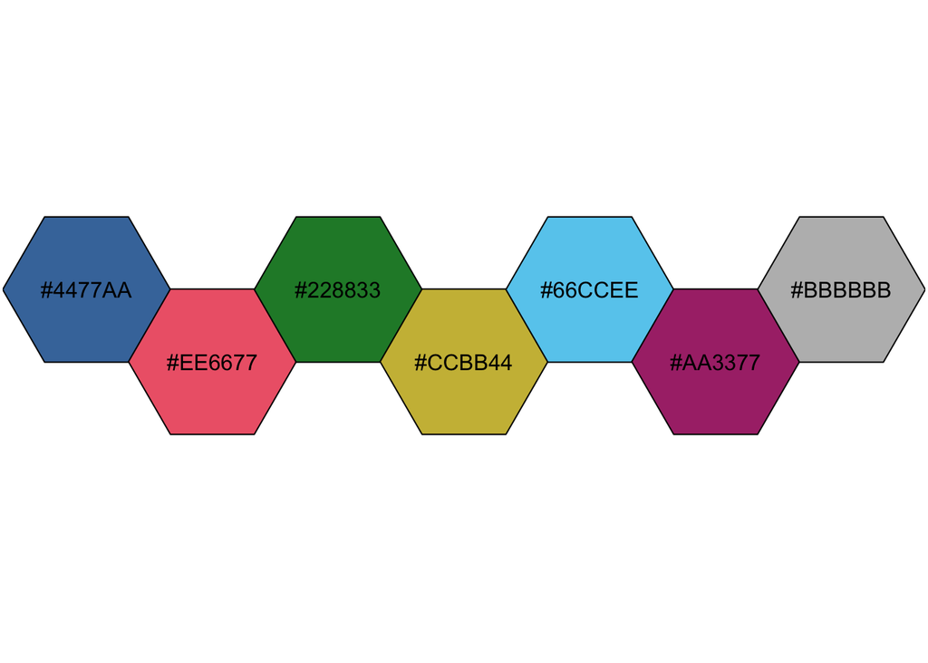

```r
# Preview the theme
plot_scheme(bright(7), colours = TRUE)
```

Use with ggplot2

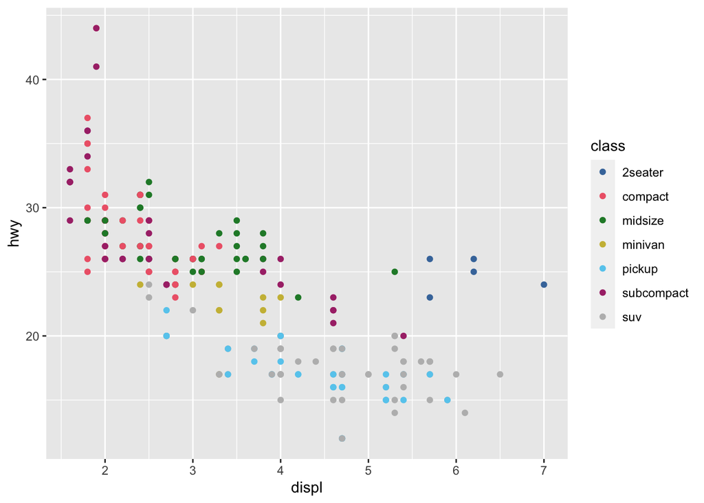

```r
data(mpg, package = "ggplot2")

ggplot2::ggplot(data = mpg) +
  ggplot2::aes(x = displ, y = hwy, colour = class) +
  ggplot2::geom_point() +
  scale_colour_bright()
```

## ggiraph - interactive graphs even in Rmd

This can do a whole lot of cool stuff more than this simple example.

More info: https://davidgohel.github.io/ggiraph/

```r
library(ggplot2)
library(ggiraph)
data <- mtcars
data$carname <- row.names(data)

gg_point = ggplot(data = data) +
    geom_point_interactive(aes(x = wt, y = qsec, color = disp,
    tooltip = carname, data_id = carname)) +
  theme_minimal()

girafe(ggobj = gg_point)
```

[interactive chart not shown]

## Patchwork - composing multiple plots together

Setting up some plots we can stitch together

```r
library(patchwork)
library(ggplot2)
p1 <- ggplot(mtcars) +
  geom_point(aes(mpg, disp)) +
  ggtitle('Plot 1')

p2 <- ggplot(mtcars) +
  geom_boxplot(aes(gear, disp, group = gear)) +
  ggtitle('Plot 2')

p3 <- ggplot(mtcars) +
  geom_point(aes(hp, wt, colour = mpg)) +
  ggtitle('Plot 3')

p4 <- ggplot(mtcars) +
  geom_bar(aes(gear)) +
  facet_wrap(~cyl) +
  ggtitle('Plot 4')
```

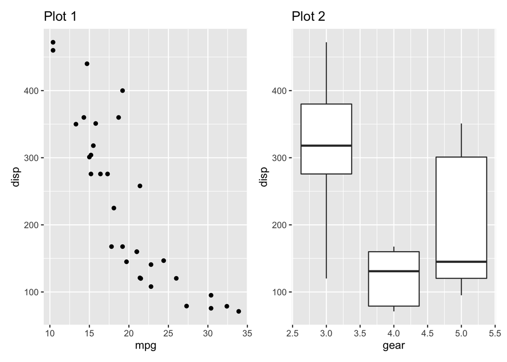

```r
p1 + p2 # combine two plots
```

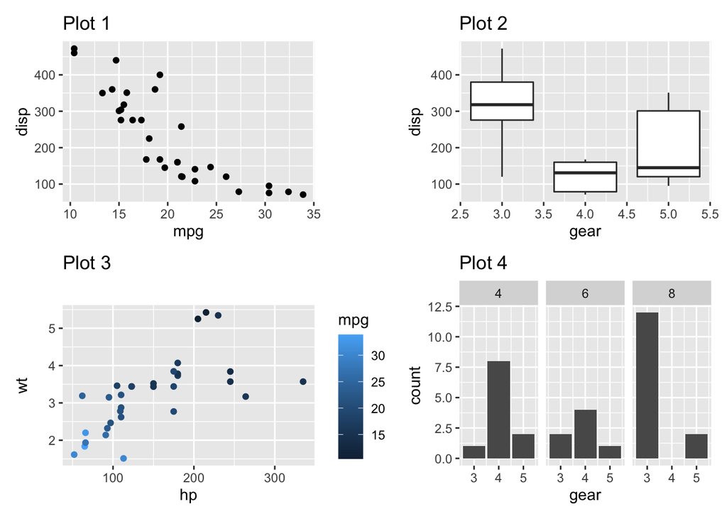

```r
p1 + p2 + p3 + p4 # by default it makes a square grid, filling rowwise
```

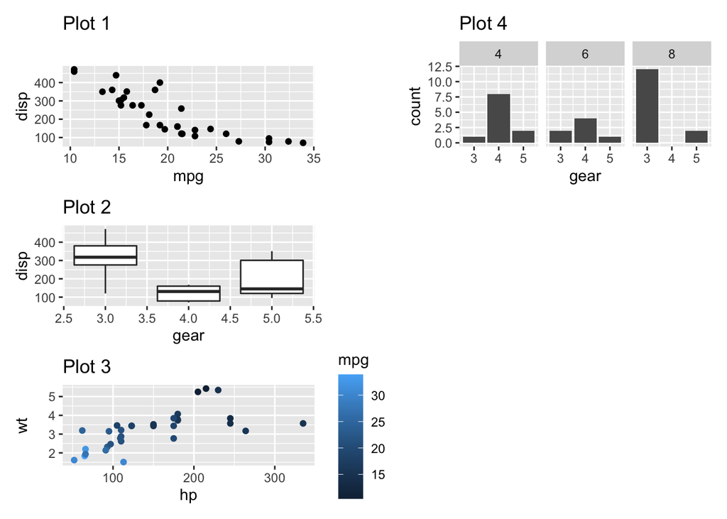

```r
# plot_layout()
p1 + p2 + p3 + p4 + plot_layout(nrow = 3, byrow = FALSE)
```

Stacking and packing plots:

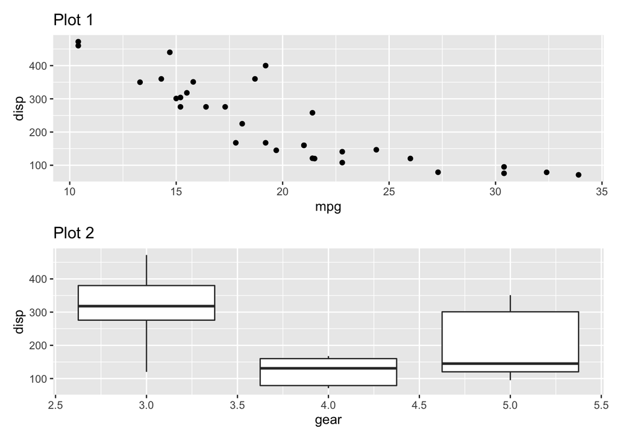

```r
p1 / p2 # / stacks one on top of the other
```

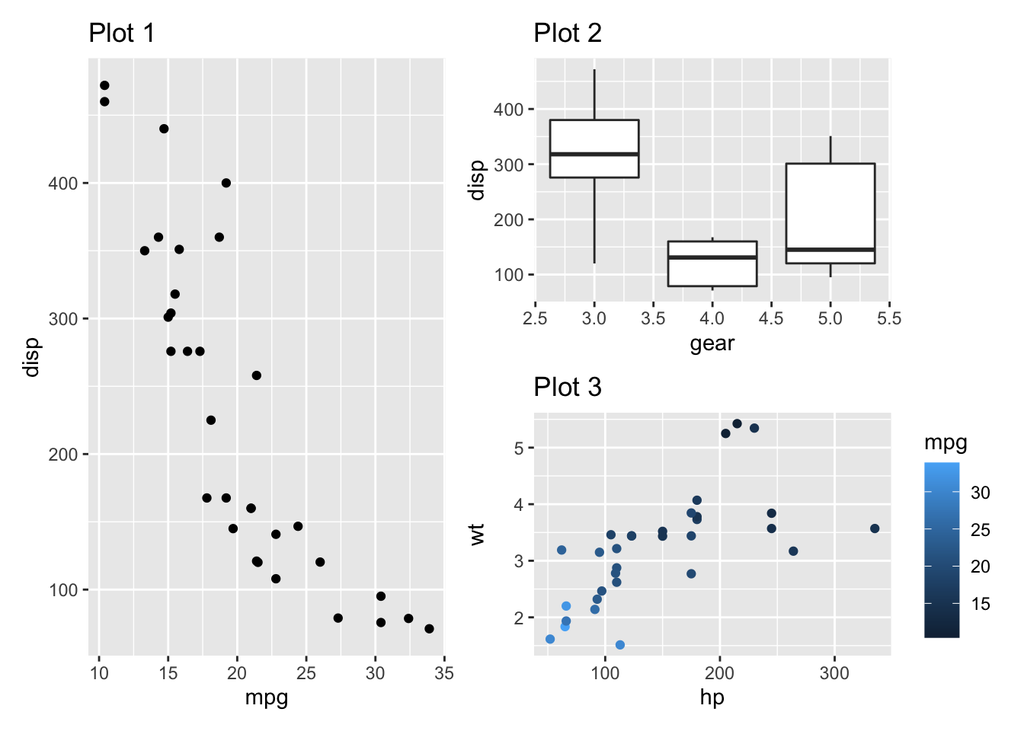

```r
p1 | (p2 / p3) # | plots side by side.  Note the parens
```

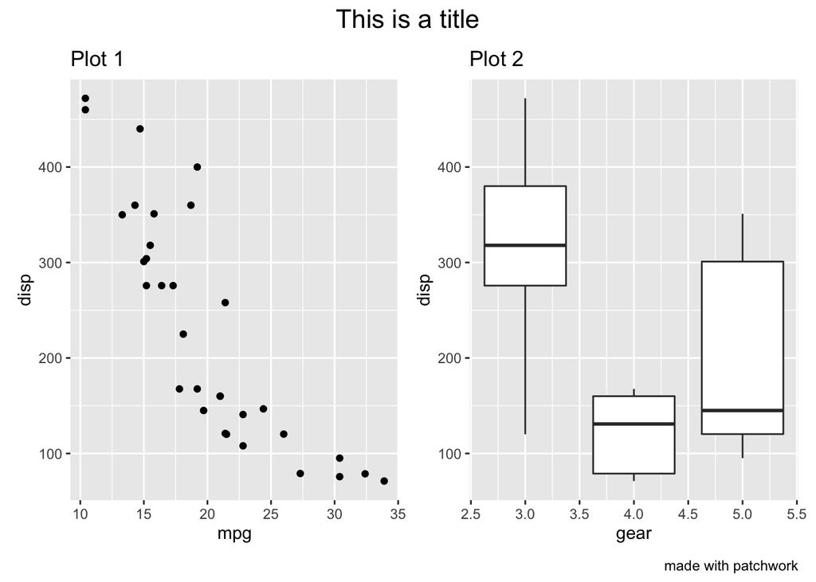

```r
p1 + p2 +
  plot_annotation(
    title = 'This is a title',
    caption = 'made with patchwork',
    theme = theme(plot.title = element_text(size = 16, hjust = 0.5))
  )
```

You can define your own layout using letters, with relative sizing

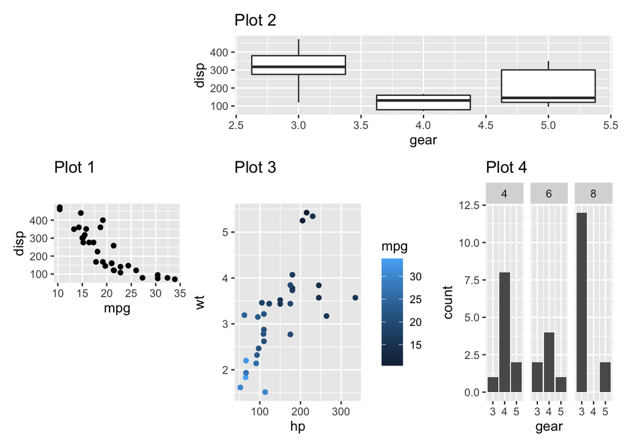

```r
layout <- "
##BBBB
AACCDD
##CCDD
"
p1 + p2 + p3 + p4 +
  plot_layout(design = layout)
```

It gets a lot more [complicated and cool](https://patchwork.data-imaginist.com/). See [here](https://patchwork.data-imaginist.com/articles/guides/multipage.html) for how this package can also avoid plots “jumping” around as you switch slides.

## Paginate faceted graphs and save as a single PDF

You can manually select which page to print:

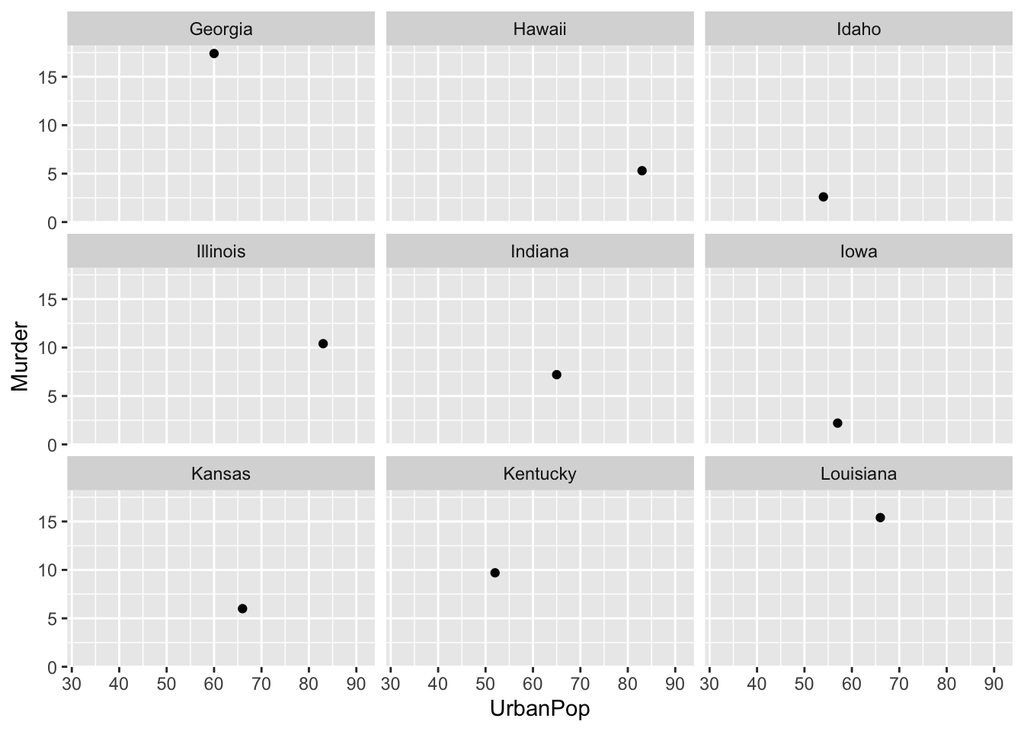

```r
USArrests %>% # dataset on US arrests
  rownames_to_column("State") %>%  # This is just so we can see the state names
  ggplot(aes(x = UrbanPop, y = Murder)) +
  geom_point() +
  ggforce::facet_wrap_paginate(~State, nrow =3, ncol = 3, page = 2)
```

Or you can be fancy and do a loop. If you know the number of pages ahead of time (which you can get with `ggforce::n_pages(p)`), you can just loop through those:

```r
cairo_pdf('filename.pdf', width = 11, height = 8.5, onefile = TRUE) #start building pdf
for (i in 1:9) {
  print( # don't forget this
    USArrests %>% # dataset on US arrests
    rownames_to_column("State") %>%  # This is just so we can see the state names
    ggplot(aes(x = UrbanPop, y = Murder)) +
    geom_point() +
    ggforce::facet_wrap_paginate(~State, nrow =3, ncol = 3, page = 2)
  )
}
dev.off() # end building pdf
```

Or you can calcuate the number of pages on the fly: (https://stackoverflow.com/questions/48544039/how-to-save-output-from-ggforcefacet-grid-paginate-in-only-one-pdf)

# Package and project management

## Package development workflow

https://r-pkgs.org: the definitive book by Wickham and Bryan, which explains lots of the stuff below

```r
devtools::load_all() # simulates installing and loading your package
devtools::document() # updates all the documentation and stuff via roxygen2
devtools::check() # run some checks when you think you're ready to release

usethis::use_version(which = c("major", "minor", "patch", "dev")) # update version number.  `which` is what level of x.y.z.dev to increment
```

## usethis

```r
# Creating
create_package()
create_project()

# Checking
proj_sitrep() # show wd, proj dir, etc

# Development
use_package() # import packages into DESCRIPTION

# Include important things
use_pipe()
use_tibble()

# Git
use_git()
use_github()
git_sitrep()
```

Also has git/github functions and other config stuff

# Modeling

## TidyModels

https://www.tidymodels.org; has a bunch of subpackages, including broom

# Data exploration

## DataExplorer

https://boxuancui.github.io/DataExplorer/

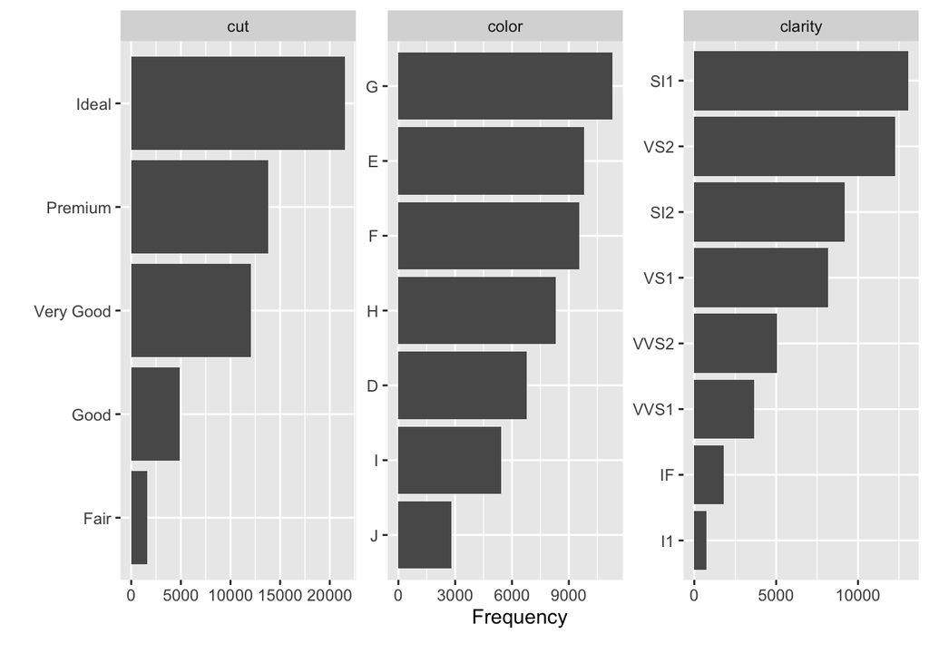

```r
library(DataExplorer)
plot_bar(ggplot2::diamonds) # Plot frequency of levels in each factor
```

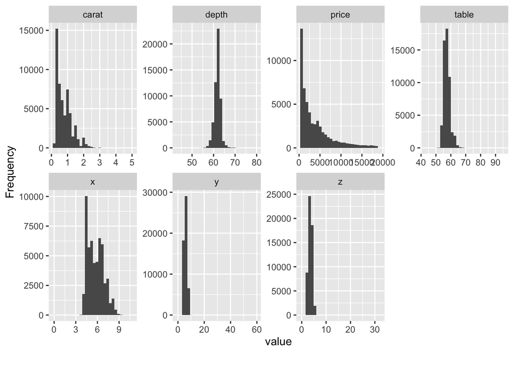

```r
plot_histogram(ggplot2::diamonds) # Histogram for all continuous variables
```

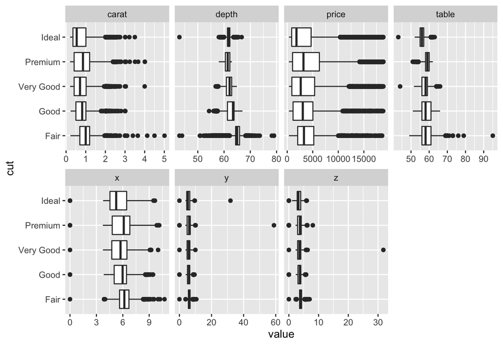

```r
plot_boxplot(ggplot2::diamonds, by = "cut")
```

# Regex

## RegExplain add-in

Select a variable name in your script, then Addins > RegExplain. You may want to type out dataframe$variable so it selects just that column.

Also Addins > RegExplain Cheatsheet has lots of helpful stuff

## rex - “friendly regular expressions”

A bunch of shortcuts to make regexprs more human-readable

```r
library(rex)
```

“shortcuts”: Commonly used character classes and regular expressions. These shortcuts are substituted inside rex calls.

NB: to have these shortcuts autocomplete in Rstudio, you must first run `rex::rex_mode()`

```r
rex::shortcuts
```

```
## $dot
## \.
##
## $any
## .
##
## $something
## .+
##
## $anything
## .*
##
## $start
## ^
##
## $end
## $
##
## $boundary
## \b
##
## $non_boundary
## \B
##
## $alnum
## [:alnum:]
##
## $alpha
## [:alpha:]
##
## $letter
## [:alpha:]
##
## $blank
## [:blank:]
##
## $cntrl
## [:cntrl:]
##
## $digit
```

[output cut: 295 more lines]

```
##
## $any_non_newlines
## ^\R*
##
## $any_non_single_quotes
## [^']*
##
## $any_non_double_quotes
## [^"]*
##
## $any_non_quotes
## [^'"]*
##
## attr(,"class")
## [1] "shortcut"
```

Capture groups:

```r
x <- c("a=1", "b=3", "a=9", "c=2", "b=4", "a=2")

matches <- re_matches(x,
                      rex(
                        capture(name="name", letter),
                        "=",
                        capture(name="value", digit)
                      ))
matches
```

```
##   name value
## 1    a     1
## 2    b     3
## 3    a     9
## 4    c     2
## 5    b     4
## 6    a     2
```

More capture groups:

```r
# extract 2,9,22,22. These characters are between the / and after the first character within the /.

mystrings <- c("X2/D2/F4",
               "X10/D9/F4",
               "X3/D22/F4",
               "X9/D22/F9")

matches <- re_matches(mystrings,
                      rex(
                        "/",
                        any,
                        capture(name = "numbers", digits)
                      )
)
as.numeric(matches$numbers)
```

```
## [1]  2  9 22 22
```

Even more more capture groups

```r
j <- "What kind of cheese isn't your cheese? (wonder) Nacho cheese! (groan) (Laugh)"

matches <- rematch2::re_match_all(j,
                      rex(
                        "(",
                        capture(name = "text", except_any_of(")")),
                        ")")) %>% unnest(text)
matches
```

```
## # A tibble: 3 × 3
##   text   .text                                                            .match
##   <chr>  <chr>                                                            <list>
## 1 wonder What kind of cheese isn't your cheese? (wonder) Nacho cheese! (… <chr>
## 2 groan  What kind of cheese isn't your cheese? (wonder) Nacho cheese! (… <chr>
## 3 Laugh  What kind of cheese isn't your cheese? (wonder) Nacho cheese! (… <chr>
```

`or()`

```r
re <- rex(or("A", "B", "C"))
str_match(re, "A")
```

```
##      [,1]
## [1,] "A"
```

```r
str_match(re, "B")
```

```
##      [,1]
## [1,] "B"
```

```r
str_match(re, "C")
```

```
##      [,1]
## [1,] "C"
```

Create character classes

```r
re <- rex("gr", one_of("a", "e"), "y") # outputs gr[ae]y
rematch2::re_match_all(c("gray", "grey"), re) %>% unnest()
```

```
## # A tibble: 2 × 2
##   .text .match
##   <chr> <chr>
## 1 gray  gray
## 2 grey  grey
```

```r
re <- rex(none_of("a", "e" ,"i", "o", "u")) # [^aeiou]
rematch2::re_match_all(c("ay", "be", "cee"), re) %>% unnest()
```

```
## # A tibble: 3 × 2
##   .text .match
##   <chr> <chr>
## 1 ay    y
## 2 be    b
## 3 cee   c
```

Escape stuff:

```r
re <- rex(escape("[hello]")) # \[hello\]
str_match("[hello]yello", re)
```

```
##      [,1]
## [1,] "[hello]"
```

```r
# If using for a string that will define a character class, use character_class_escape() instead
```

Wildcards

```r
re <- rex(zero_or_more(digit))
str_extract_all("123abc456", re)
```

```
## [[1]]
## [1] "123" ""    ""    ""    "456" ""
```

```r
re <- rex(one_or_more(digit))
str_extract_all("123abc456", re)
```

```
## [[1]]
## [1] "123" "456"
```

```r
re <- rex(maybe(digit))
str_extract_all("123abc456", re)
```

```
## [[1]]
##  [1] "1" "2" "3" ""  ""  ""  "4" "5" "6" ""
```

## rematch2 - like str_match(_all), except put it in a tidy tibble instead of a list

(May want to follow with `%>% unnest()` to expand the list-columns)

```r
name_rex <- paste0(
  "(?<first>[[:upper:]][[:lower:]]+) ",
  "(?<last>[[:upper:]][[:lower:]]+)"
)
notables <- c(
  "  Ben Franklin and Jefferson Davis",
  "\tMillard Fillmore"
)
not <- rematch2::re_match_all(notables, name_rex)

not
```

```
## # A tibble: 2 × 4
##   first     last      .text                                .match
##   <list>    <list>    <chr>                                <list>
## 1 <chr [2]> <chr [2]> "  Ben Franklin and Jefferson Davis" <chr [2]>
## 2 <chr [1]> <chr [1]> "\tMillard Fillmore"                 <chr [1]>
```

```r
not %>% unnest(c(first, last))
```

```
## # A tibble: 3 × 4
##   first     last     .text                                .match
##   <chr>     <chr>    <chr>                                <list>
## 1 Ben       Franklin "  Ben Franklin and Jefferson Davis" <chr [2]>
## 2 Jefferson Davis    "  Ben Franklin and Jefferson Davis" <chr [2]>
## 3 Millard   Fillmore "\tMillard Fillmore"                 <chr [1]>
```

# Sorting

## naturalsort - sort numbers without having to left-zero-pad them

```r
sprintf("hoge%s", 1:12) %>% sample(.) %>%
  naturalsort::naturalsort(.) %>% print()
```

```
##  [1] "hoge1"  "hoge2"  "hoge3"  "hoge4"  "hoge5"  "hoge6"  "hoge7"  "hoge8"
##  [9] "hoge9"  "hoge10" "hoge11" "hoge12"
```

# Etc

## Progress bars with `progress`

```r
list_to_traverse <- 1:10

# Set up the progress bar
pb <- progress::progress_bar$new(total = 10,
                                 format = "  [:bar] :spin :percent (:current/:total) in :elapsedfull (eta: :eta) ",
                                 clear = FALSE)
purrr::walk(list_to_traverse,
            function(x) {
              Sys.sleep(.5)
              pb$tick() #call pb$tick() after each iteration
            })

beepr::beep(sound = "fanfare") # play a sound after
```

You can also do this inline in a one-sided formula (~). NB that the entire one-sided formula after the ~ must be in {curly braces} and use semicolon to separate “lines”

```r
purrr::walk(list_to_traverse,
            ~ {Sys.sleep(.5); pb$tick()}
            )
```

Package `asbutils` has a version of `progress_bar` with sane defaults:

```r
pb <- asbutils::asb_progress(total = 10)
```

## datapasta - copy/paste data

```r
library(datapasta)
```

Paste as a tribble or as a df

| A | B | C | D | E |
| --- | --- | --- | --- | --- |
| 1 | 4 | 5 | 7 | 9 |
| 8 | 5 | 8 | 0 | 8 |
| 5 | 6 | 8 | 9 | 0 |

```r
datapasta::tribble_paste()
# Pastes the following
# tibble::tribble(
#      ~A, ~B, ~C, ~D, ~E,
#      1L, 4L, 5L, 7L, 9L,
#      8L, 5L, 8L, 0L, 8L,
#      5L, 6L, 8L, 9L, 0L
#      )

datapasta::df_paste()
# data.frame(
#            A = c(1L, 8L, 5L),
#            B = c(4L, 5L, 6L),
#            C = c(5L, 8L, 8L),
#            D = c(7L, 0L, 9L),
#            E = c(9L, 8L, 0L)
#    )
```

| A | B | C | D | E |
| --- | --- | --- | --- | --- |

```r
datapasta::vector_paste()
# Pastes the following
# c("A", "B", "C", "D", "E")

datapasta::vector_paste_vertical()
# c("A",
#      "B",
#      "C",
#      "D",
#      "E")
```

Get data from an existing table into usable format - useful for making a reprex/mwe!

```r
paste_me <- tibble::tribble(
     ~A, ~B, ~C, ~D, ~E,
     1L, 4L, 5L, 7L, 9L,
     8L, 5L, 8L, 0L, 8L,
     5L, 6L, 8L, 9L, 0L
     )

dpasta(paste_me)
# Pastes the following
# tibble::tribble(
#      ~A, ~B, ~C, ~D, ~E,
#      1L, 4L, 5L, 7L, 9L,
#      8L, 5L, 8L, 0L, 8L,
#      5L, 6L, 8L, 9L, 0L
#      )

# dmdclip(paste_me) does the same as dpasta, but pastes to keyboard
```

Two useful Addins: `Toggle Vector Quotes` highlight a c() expression and it either wraps or unwraps all elements with double quotes

`Fiddle Selection` does a bunch:

- If you highlight raw data (separated by commas, spaces, newlines), it will turn it into a c()
- If you select a c() expression, will toggle between horizontal and vertical
- If you select a tribble or df, reflows it pretty-like

# When upgrading R

If you upgrade R to a new major or minor release (eg, 1.3 or 2.0), you will lose all packages that are installed!

ALWAYS install new versions of R using the installer from the official R page—DO NOT USE HOMEBREW

BEFORE upgrading, get a list of all your packages:

```r
devtools::package_info("installed")
```

This will give a df showing package names, versions, and where they’re from (CRAN or github). Save this somewhere so you can read it back in after you install the upgrade.

Next, get a list of which addins you have active from rsam. Run rsam::rsam(), open it in Safari, and then copy/paste the list into TextEdit. You’ll have to manually re-enter all this stuff using rsam::rsam() after the upgrade.

Now, upgrade.

Then after installing, filter by source and install as appropriate. Will need to install `devtools` first

```r
CRAN_packages <- devtools::package_info("installed") %>% filter(str_detect(source, "CRAN"))
github_packages <- devtools::package_info("installed") %>% filter(str_detect(source, "Github"))
```

```r
install.packages(CRAN_packages$package)
install_github(github_packages$package)
```

# Stuff to add

(broom)[https://broom.tidymodels.org] to tidy up models

```r
a <- b <- matrix(1:100, ncol=2)
a <- a[-20,]
b <- b[-45,]
b[c(18, 44)] <- 999
diffobj::diffPrint(target=a, current=b)
```

```
## < a                > b
## @@ 17,6 @@         @@ 17,7 @@
## ~       [,1] [,2]  ~       [,1] [,2]
##   [16,]   16   66    [16,]   16   66
##   [17,]   17   67    [17,]   17   67
## < [18,]   18   68  > [18,]  999   68
##   [19,]   19   69    [19,]   19   69
## ~                  > [20,]   20   70
##   [20,]   21   71    [21,]   21   71
##   [21,]   22   72    [22,]   22   72
## @@ 42,6 @@         @@ 43,5 @@
##   [41,]   42   92    [42,]   42   92
##   [42,]   43   93    [43,]   43   93
## < [43,]   44   94  > [44,]  999   94
## < [44,]   45   95  ~
##   [45,]   46   96    [45,]   46   96
##   [46,]   47   97    [46,]   47   97
```

Nesting - unnest, unnest_longer, unnest_wider, hoist (tidyr)

https://uribo.github.io/rpkg_showcase/index.html

http://personality-project.org/r/psych/

https://github.com/eddelbuettel/anytime VS lubridate

zoo - rollmean(), rollapply()…

lobstr package

iris %>% boomer::boom()

https://github.com/Pakillo/grateful

https://cran.r-project.org/web/packages/report/vignettes/report.html

https://cran.r-project.org/web/packages/MBESS/index.html

https://rpkgs.datanovia.com/ggpubr/index.html